# StepsReport

Haijing

12/4/2020

## Steps Analysis

This report analyses the steps monitor data collected from one person over multiple days.

#### Step 1: We will unpack original data file, read data into R and convert date into Date format.

```r
library(dplyr)
```

```r
library(ggplot2)
## unzip("activity.zip")
activity <- read.csv("activity.csv", header=TRUE)
activity <- mutate(activity, date = as.Date(date, format="%Y-%m-%d"))
```

#### Step 2: Sum up daily steps, calculate mean and median of steps per day

We will sum steps by date, then plot a histogram of it

```r
activity %>% group_by(date) %>% summarize(dailysteps = sum(steps, na.rm=TRUE)) -> dailysteps
```

```r
p1 <- qplot(dailysteps$dailysteps, geom="histogram", bins=12,
      main="Histogram for Daily steps", xlab = "# of Steps per day",
      ylab="Number of Days", fill = I("Steelblue"), col=I("red"))
mean <- mean(dailysteps$dailysteps)
median <- median(dailysteps$dailysteps)
```

Histogram of daily steps taken is as following:

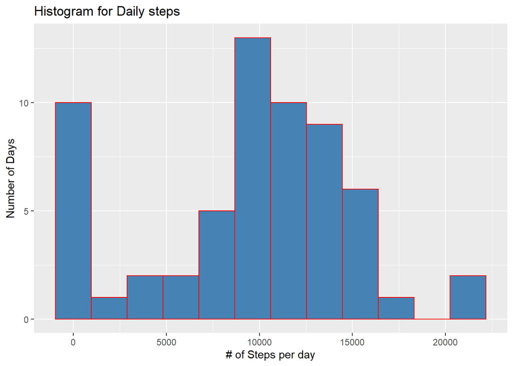

The mean of total steps taken per day is 9354.2295082  
The median of total steps taken per day is 10395

#### Step 3: What is the average daily activity pattern?

We will group data by interval number, then calculate average steps per interval.

```r
activity %>% group_by(interval) %>% summarize(steps= mean(steps, na.rm=TRUE)) -> intervalsteps
```

```r
p2 <- ggplot(intervalsteps, aes(x = interval, y=steps)) + geom_line(color="blue")
```

Average steps per interval over days plot:

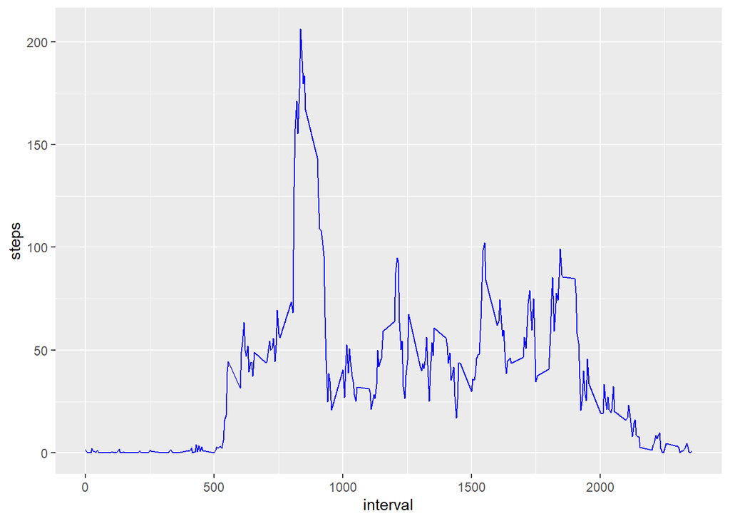

Interval with maximum average steps is 835

#### Step 4: Imputing missing values

Total number of records with missing values is 2304  
Percentage of records with missing values is 0.1311475

We are going to fill in missing value with mean of 5 minute interval steps computed in step 3. Then we will re-calculate sum of daily steps.

```r
filled <- data.frame(activity)
whichna <- which(is.na(filled$steps))
for( val in whichna){
  itv <- filled[val, 3]
  filled[val, 1] <- intervalsteps[intervalsteps$interval==itv, 2]
}

filled %>% group_by(date) %>% summarize( stepsPerDay = sum(steps, na.rm=TRUE)) -> imputed
```

```r
p3 <- qplot(imputed$stepsPerDay, geom="histogram", bins=12,
      main="Histogram for Daily steps Imputed", xlab = "# of Steps per day",
      ylab="Number of Days", fill = I("Orange"), col=I("black"))
imputedmean <- mean(imputed$stepsPerDay)
imputedMedian <- median(imputed$stepsPerDay)
```

Histogram of Daily number of steps with imputed data is as following:

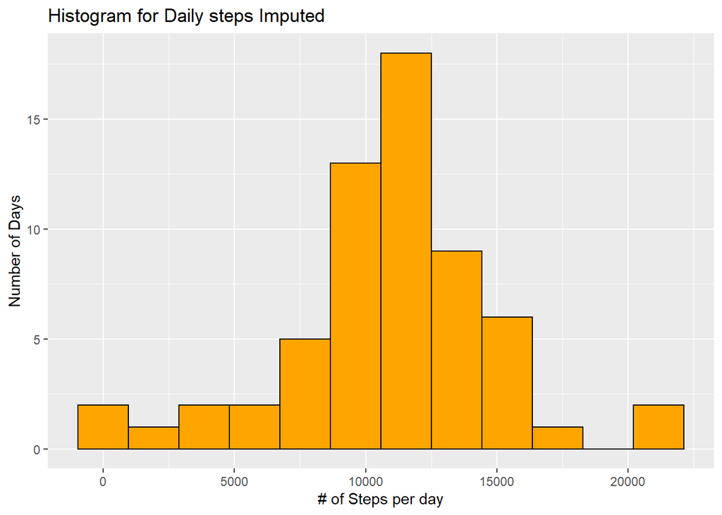

#### Step 5: Acitvity pattern comparison between weekdays and weekends

Using imputed dataset, compute average number of steps per interval for weekdays and weekends. Plot them in two panels vertically to visualize.

```r
weekends <- c("Saturday", "Sunday")
twopattern <- mutate(filled, ifweekend = ( weekdays(date) %in% weekends))
twopattern %>% group_by(interval, ifweekend) %>% summarize(steps= mean(steps, na.rm=TRUE)) -> newstep
```

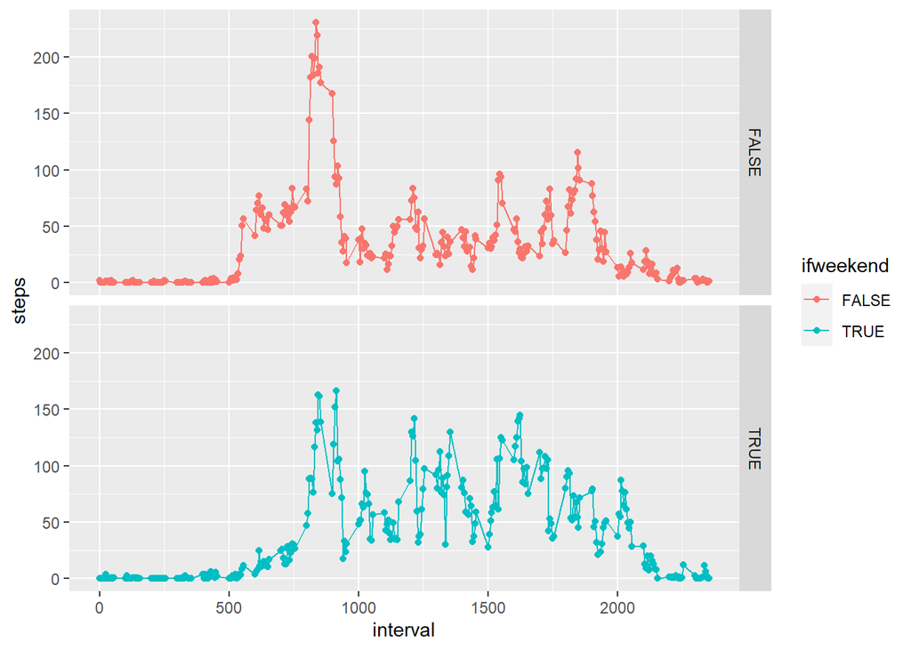

```r
p4 <- ggplot(newstep, aes(x = interval, y=steps), group=ifweekend)
p4 <- p4 + geom_line(aes(color=ifweekend)) + geom_point(aes(color=ifweekend))
p4 <- p4 + facet_grid(ifweekend ~ .)
print(p4)
```